# Kilpisjärvi PIT demo for Bayesian Workflow book

Author

Aki Vehtari

Published

2024-06-27

Modified

2026-07-18

This notebook includes part of the code for the Bayesian Workflow book Section 8.2 about posterior predictive checking.

**Load packages**

```r
library(rprojroot)
root <- has_file(".Bayesian-Workflow-root")$make_fix_file()
library(loo)
library(brms)
options(brms.backend = "cmdstanr", mc.cores = 1)
# devtools::load_all("~/proj/bayesplot")
library(bayesplot)
ggplot2::theme_set(bayesplot::theme_default(base_family = "sans", base_size=14))
SEED <- 48927 # set random seed for reproducibility
```

# 1 Linear Gaussian model

```r
data_kilpis <- read.delim(root("digits/data", "kilpisjarvi-summer-temp.csv"), sep = ";")
data_lin <- data.frame(year = data_kilpis$year,
                       temp = data_kilpis$temp.summer)
```

To analyse whether there has been change in the average summer month temperature we use a linear model with Gaussian model for the unexplained variation. By default brms uses uniform prior for the coefficients.

Formula `temp ~ year` corresponds to model $\mathrm{temp} ~ \mathrm{normal}(\alpha + \beta \times \mathrm{temp}, \sigma)$. The model could also be defined as `temp ~ 1 + year` which explicitly shows the intercept ($\alpha$) part. Using the variable names `brms` uses the model can be written also as
$$\mathrm{temp} \sim \mathrm{normal}(\mathrm{b\_Intercept}*1 + \mathrm{b\_year}*\mathrm{year}, \mathrm{sigma})$$
In this case, we are happy with the default prior for the intercept. In this specific case, the flat prior on coefficient is also fine, but we add a weakly informative prior just for the illustration. Let’s assume we expect the temperature to change less than 1°C in 10 years. With `student_t(3, 0, 0.03)` about 95% prior mass has less than 0.1°C change in year, and with low degrees of freedom (3) we have thick tails making the likelihood dominate in case of prior-data conflict. In real life, we do have much more information about the temperature change, and naturally a hierarchical spatio-temporal model with all temperature measurement locations would be even better.

```r
fit_lin <- brm(temp ~ year, data = data_lin, family = gaussian(),
               prior = prior(student_t(3, 0, 0.03), class="b"),
               seed = SEED, refresh = 0)
```

Check the summary of the posterior and inference diagnostics.

```r
fit_lin
```

```
 Family: gaussian
  Links: mu = identity
Formula: temp ~ year
   Data: data_lin (Number of observations: 62)
  Draws: 4 chains, each with iter = 2000; warmup = 1000; thin = 1;
         total post-warmup draws = 4000

Regression Coefficients:
          Estimate Est.Error l-95% CI u-95% CI Rhat Bulk_ESS Tail_ESS
Intercept   -28.42     15.42   -57.59     1.82 1.00     3484     2893
year          0.02      0.01     0.00     0.03 1.00     3473     2947

Further Distributional Parameters:
      Estimate Est.Error l-95% CI u-95% CI Rhat Bulk_ESS Tail_ESS
sigma     1.13      0.10     0.95     1.35 1.00     3742     3275

Draws were sampled using sample(hmc). For each parameter, Bulk_ESS
and Tail_ESS are effective sample size measures, and Rhat is the potential
scale reduction factor on split chains (at convergence, Rhat = 1).
```

Posterior predictive check with density overlays examines the whole temperature distribution. We generate replicate data using 20 different posterior draws (with argument `ndraws`).

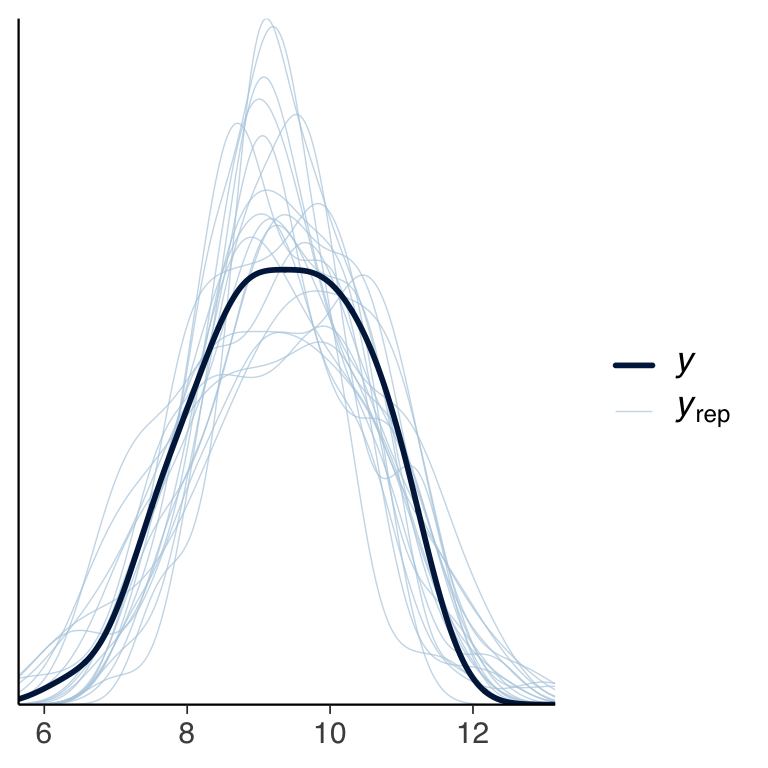

Figure 1

```r
pp_check(fit_lin, type="dens_overlay", ndraws=20)
```

In a posterior predictive check which compares pointwise posterior predictive intervals and the observations, the proportion of the observations within the shown 50% and 90% intervals should be approximately 50% and 90%.

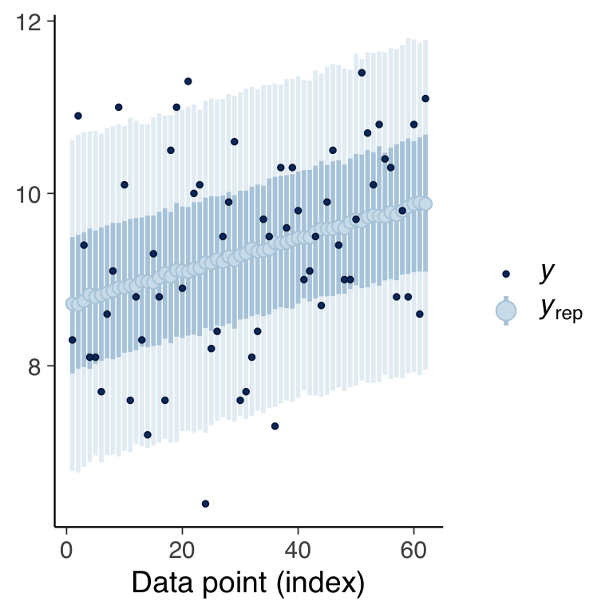

Figure 2

```r
pp_check(fit_lin, type="intervals")
```

Instead of counting the proportion of observations only in some interval lengths, we can emaine all cumulative densities. If the predictive distributions match well the data (are well calibrated) then the pointwise cumulative densities have distribution which is close to uniform. The cumulative densities are also known as probability integral transformations (PIT). We can compare empirical CDF of observed PITs to uniform distribution and to associated simulatanous confidence interval shown as an envelope. If the PIT ECDF stays inside the envelope, the predictive distributions are well calibrated.

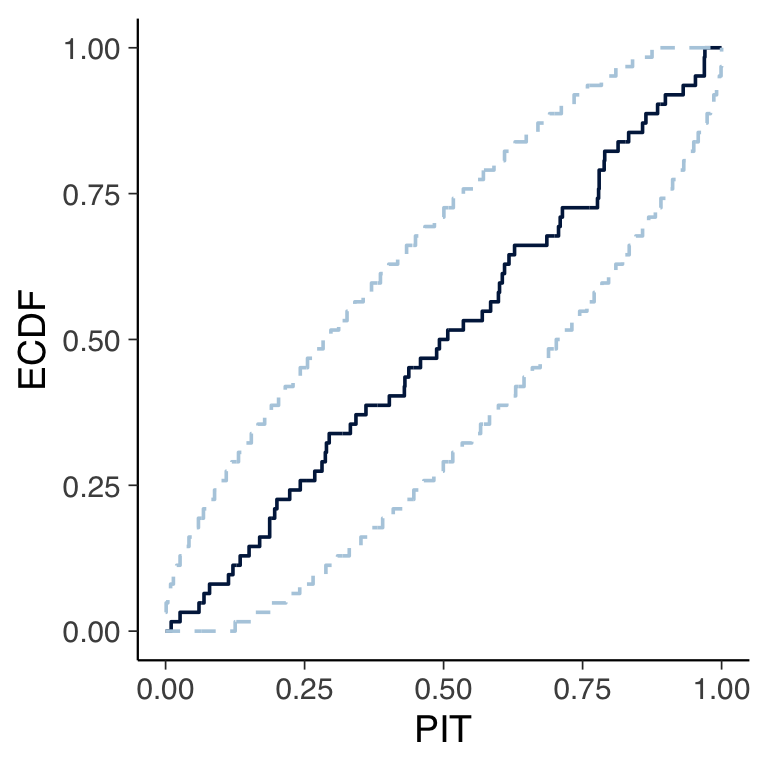

Figure 3

```r
set.seed(SEED)
pp_check(fit_lin, type="pit_ecdf", method = "correlated")
```

There can be a lot of white space in an ECDF plot, and sometimes we prefer to plot a difference from the expected ECDF to improve the dynamic range of the plot.

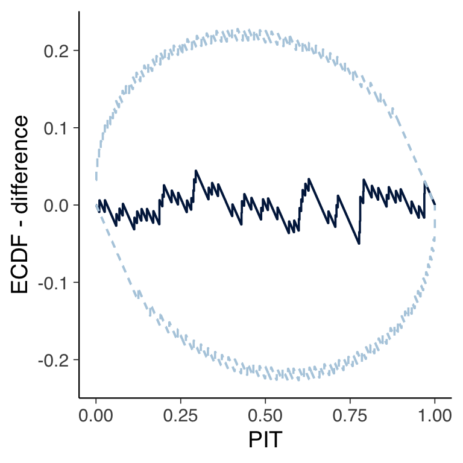

Figure 4

```r
set.seed(SEED)
pp_check(fit_lin, type="pit_ecdf", method = "correlated", plot_diff=TRUE)
```

In this example, the number of observations is much higher than the number of parameters in the model and there is not much difference in whether we use posterior predictive or cross-validation predictive distributions in the model checking (Tesso and Vehtari 2026). In case of more flexible models it is better to use LOO predictive intervals and LOO-PIT (Tesso and Vehtari 2026).

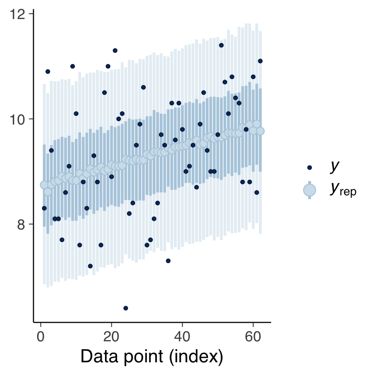

Figure 5

```r
pp_check(fit_lin, type="loo_intervals")
```

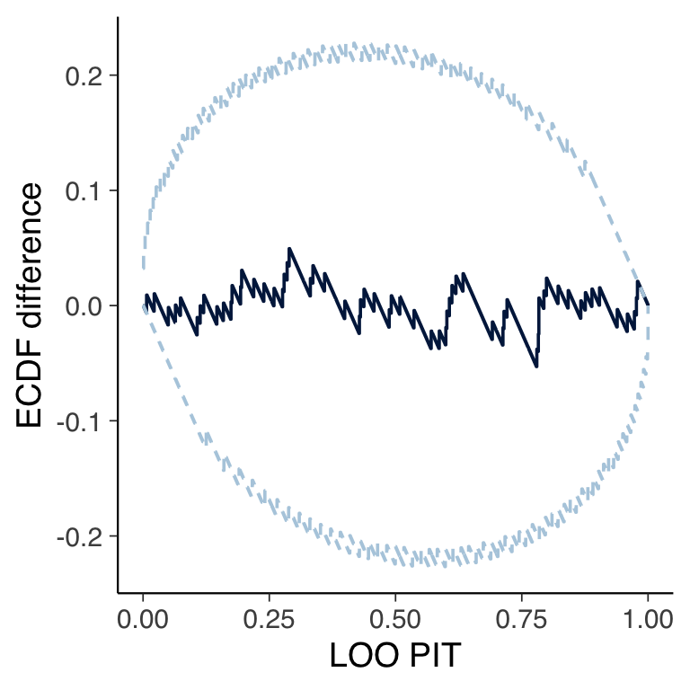

Figure 6

```r
set.seed(SEED)
pp_check(fit_lin, type="loo_pit_ecdf", method = "correlated", plot_diff=TRUE)
```

## References

Tesso, Herman, and Aki Vehtari. 2026. “LOO-PIT Predictive Model Checking.” *arXiv Preprint arXiv:2603.02928*.